# IODS project

Ville Harjunen

15 helmikuuta 2017

# About the project

## Description of the IODS course

The introduction to data science course takes us to a tour that introduces us to the core themes of open data science. Along the course we will learn the principles and advantages of using open research tools and open data to do reproducible research. To achieve this goal, We wil learn how to use some of the most common open rresearch tools, such R, Rstudio, Rmarkdown and GitHub. In addtition, we well learn to apply these tools for running a set of statistical methods, including linear models and data clustering.

The link attached below will take you to my GitHub repository where you can find my Rstudio projects.

https://github.com/villehar/IODS-project

## First week: Tools and methods for open and reproducible research

I started this week’s assignments by doing the DataCamp exercises (R Short and sweet) introducing me to the R language and the basics of Rstudio. I learned how to create objects, functions, and how to read data files as data frames consisting of multiple vectors.

The DataCamp experience came in use when carrying out the first Rstudio exercise. I started the exercise by creating an account to GitHub and linking the account to the course project template using the “forking” operation. Then, I downloaded the SmartGit software to upload the R markdown files to my course repository (https://github.com/villehar/IODS-project). Before downloading the SmartGit I used couple of moments struggling with the GitHub destop (another software for the same purpose as the SmartGit) in order to acces the files (e.g. chapter1.Rmd) in the repository file. However, I did not manage to do so with GitHub destop and used SmartGit instead.

Next, I opened the chapter1.Rmd file in Rstudio and wrote a short description of the course while using the Rmarkdown commands in order to create titles and *subtitles* as well as other adjustments to the text layout. Then I knitted the HTML document and checked that everything looked as it shoul.

In the third task, I opened the index.Rmd file in Rstudio and added author:“Your Name” below the title option in the R markdown syntax. I again finished the part by clicking the Knit button in the graphical interface of Rstudio.

In the fouth task, I created a new R markdown file. When opening the file, the system automatically added some example syntax on the page. After playing around with those syntaxes I removed all the exmaple code and added a new title (Course diary), subtitles (First Week) and wrote couple of lines about the course. When saving the new Rmd file to my IODS-project folder, I named is as README.Rmd as recuested. Finally, I changed the theme of the htlm codument to *sandstone* to changes the appearance of the page.

After finishing all the tasks, I uploaded the changes made to my local repository files to GitHub

## Second week: Regression and model varidation

### Rstudio Exercise 2

I started the exercise by creating a folder “data” to my local IODS-project folder and saving a R script “create_learning2014” there. Then I read the “learning2014” data into R and prepared the data for the analysis stage. Further description of the data wrangling can be found in the “create_learning2014.R” script.

Below you can see the resulting file which has 166 observations (rows) and 7 variables (columns). The dataset describes students’ ratings of learning styles (deep, surface and strategic), attitudes towards mathematics, exam points, and demographic informations.

```r
Data14 = read.csv(file = "data/learning2014.csv", header = TRUE)
Data14 <- Data14[,c(4,1,2,3,5,6,7)]
dim(Data14)
```

```
## [1] 166   7
```

```r
str(Data14)
```

```
## 'data.frame':    166 obs. of  7 variables:
##  $ gender  : Factor w/ 2 levels "F","M": 1 2 1 2 2 1 2 1 2 1 ...
##  $ Age     : int  53 55 49 53 49 38 50 37 37 42 ...
##  $ Attitude: int  37 31 25 35 37 38 35 29 38 21 ...
##  $ Points  : int  25 12 24 10 22 21 21 31 24 26 ...
##  $ deep    : num  3.58 2.92 3.5 3.5 3.67 ...
##  $ surf    : num  2.58 3.17 2.25 2.25 2.83 ...
##  $ stra    : num  3.38 2.75 3.62 3.12 3.62 ...
```

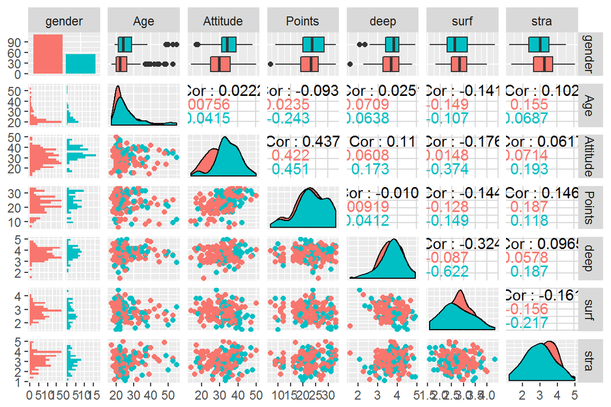

```r
library(GGally)
library(ggplot2)
explorative_plot <- ggpairs(Data14, mapping = aes(col = gender), lower = list(combo = wrap("facethist", bins = 20)))
explorative_plot
```

Based on the preliminary inspection, I then selected three variables (attitude, stra and surf) as independent variables and points as the dependent variable and fitted a multiple regression model. Summary of the model revealed a statistically significant effect of attitude on exam points indiacting that more positive attitudes toward mathematics were associated to higher performance in the exam. The estimated effects of strategic and surface learning style were not significant. The multiple R-squared (0.2074) indicated that the model predicted about 21 percent of the variation in students’ exam points.

Given that both stra and surf were not significant, I removed them from the model and fitted it again (model2) with a single predictor (attitude). The estimated slope of attitude became slightly higher compared to the model1 whereas the multiple R-squared decreased to 0.1906. The mode2 proofed to be better as it was much simpler and had almost the same explanatory power with only one predictor. The observed multible R-squared of 0.1906 indicated that about 19 percent of the variability in the response (points) was explained by the attitude variable.

```r
model1 <- lm(Points ~ Attitude + stra + surf, data = Data14)
summary(model1)
```

```
##
## Call:
## lm(formula = Points ~ Attitude + stra + surf, data = Data14)
##
## Residuals:
##      Min       1Q   Median       3Q      Max
## -17.1550  -3.4346   0.5156   3.6401  10.8952
##
## Coefficients:
##             Estimate Std. Error t value Pr(>|t|)
## (Intercept) 11.01711    3.68375   2.991  0.00322 **
## Attitude     0.33952    0.05741   5.913 1.93e-08 ***
## stra         0.85313    0.54159   1.575  0.11716
## surf        -0.58607    0.80138  -0.731  0.46563
## ---
## Signif. codes:  0 '***' 0.001 '**' 0.01 '*' 0.05 '.' 0.1 ' ' 1
##
## Residual standard error: 5.296 on 162 degrees of freedom
## Multiple R-squared:  0.2074, Adjusted R-squared:  0.1927
## F-statistic: 14.13 on 3 and 162 DF,  p-value: 3.156e-08
```

```r
model2 <- lm(Points ~ Attitude, data = Data14)
summary(model2)
```

```
##
## Call:
## lm(formula = Points ~ Attitude, data = Data14)
##
## Residuals:
##      Min       1Q   Median       3Q      Max
## -16.9763  -3.2119   0.4339   4.1534  10.6645
##
## Coefficients:
##             Estimate Std. Error t value Pr(>|t|)
## (Intercept) 11.63715    1.83035   6.358 1.95e-09 ***
## Attitude     0.35255    0.05674   6.214 4.12e-09 ***
## ---
## Signif. codes:  0 '***' 0.001 '**' 0.01 '*' 0.05 '.' 0.1 ' ' 1
##
## Residual standard error: 5.32 on 164 degrees of freedom
## Multiple R-squared:  0.1906, Adjusted R-squared:  0.1856
## F-statistic: 38.61 on 1 and 164 DF,  p-value: 4.119e-09
```

Sometimes the coefficient estimates are biased because the regression model does not actually fit the data. To see whether the assuptions of linear models were met, I ran a set of model diagnostics, namely plots of residuals vs Fitted values, Normal QQ-plot and Residuals vs Leverage.

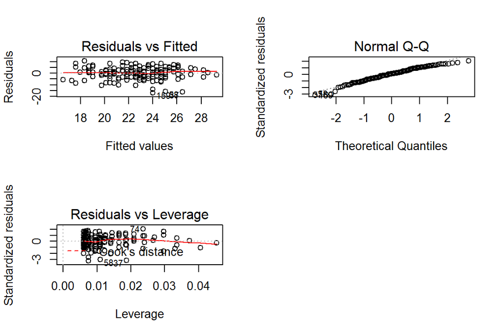

```r
par(mfrow = c(2,2))
plot(model2, which = c(1,2,5))
```

Plotting the residuals against fitted values revealed no signs of heteroscedasticity meaning that the residuals and the fitted values were uncorrelated. The assumption of normally distributed errors was also met because the deviations of residuals from the theoretical normal distribution were mininal. Finally, plotting the standardized residuals against leverage revealed no clear influential outlier cases. All cases were well in the reach of the Cook’s distance line.

# Week 3: Logistic regression

## Data Wrangling exercise

I started the exercise creating a R script “create_alc.R” and saving it to the “data” folder of my local project repository. Then I read the “student-mat” and “student-por” data sets into R and merged them for the analysis stage. Further description of the data wrangling can be found in the “create_alc.R” script.

## Data analysis exercise

Below you can see the resulting alc data which has 382 observations (rows) and 35 variables (columns).

```r
alc = read.csv(file = "data/student_alc.csv", header = TRUE)

dim(alc)
```

```
## [1] 382  35
```

```r
colnames(alc)
```

```
##  [1] "school"     "sex"        "age"        "address"    "famsize"
##  [6] "Pstatus"    "Medu"       "Fedu"       "Mjob"       "Fjob"
## [11] "reason"     "nursery"    "internet"   "guardian"   "traveltime"
## [16] "studytime"  "failures"   "schoolsup"  "famsup"     "paid"
## [21] "activities" "higher"     "romantic"   "famrel"     "freetime"
## [26] "goout"      "Dalc"       "Walc"       "health"     "absences"
## [31] "G1"         "G2"         "G3"         "alc_use"    "high_use"
```

The dataset describes students’ alcohol consumption, absence from school and exam grades. It also contains information regarding students’ school, sex, age and other backgroud informaation. The alc_use variable describes alcohol use averaged over week and weekend and the high_use is a logical variable of high alcohol use. The data was uploaded from the UCI Machine Learning repository https://archive.ics.uci.edu/ml/datasets/STUDENT+ALCOHOL+CONSUMPTION.

Before running any analyses I selected the “high_use” as my outcome variable and “sex”, “absences,”goout" (going out with friends), and “G3” (grade from the final exam) as predictors. My hypotheses were as follows:

H1: there are more high alcohol consumption in males than females H2: higher absence rates predict higher likelihood of high use H3: Lower grades in the final exam are related to higher probability of high use H4: Higher levels of goout are related to higher probability of high use

Next, I created a subset of the aforementioned variables and saved it into alc_small

```r
alc_small <- alc[, c(2, 26, 30,33,35)]
```

When graphically exploring the distributions of the chosen variables it was found that only the goout was normally distributed. There were almost equal amount of males and females and there were about 100 high users and 300 with low alcohol consumption.

```r
library(tidyr); library(dplyr); library(ggplot2)
gather(alc_small) %>% glimpse
```

```
## Observations: 1,910
## Variables: 2
## $ key   <chr> "sex", "sex", "sex", "sex", "sex", "sex", "sex", "sex", ...
## $ value <chr> "F", "F", "F", "F", "F", "M", "M", "F", "M", "M", "F", "...
```

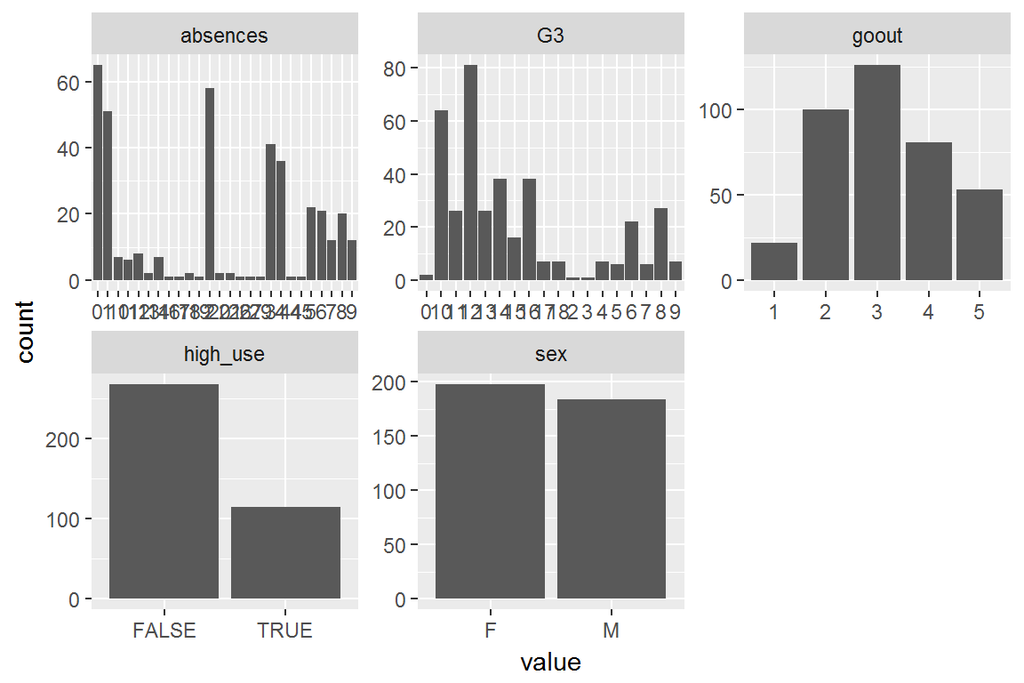

```r
gather(alc_small) %>% ggplot(aes(value)) + facet_wrap("key", scales = "free") + geom_bar()
```

To better understand the relationship of the selected predictors to alcohol use, I printed out a crosstable. That revealed that there were more high users in males and that the grades of high user males were lower than low user males. Additionally, the absences and goout ratings were also higer in high use students.

To sum up, these preliminary findings give support to my hypotheses. The only exception are the exam grades. There the relationship between low grades and alcohol use is only present in males.

```r
alc_small %>% group_by(sex, high_use) %>% summarise(count = n(), mean_grade = mean(G3), Absences = mean(absences), Going_out = mean(goout))
```

```
## Source: local data frame [4 x 6]
## Groups: sex [?]
##
##      sex high_use count mean_grade Absences Going_out
##   <fctr>    <lgl> <int>      <dbl>    <dbl>     <dbl>
## 1      F    FALSE   156   11.39744 4.224359  2.955128
## 2      F     TRUE    42   11.71429 6.785714  3.357143
## 3      M    FALSE   112   12.20536 2.982143  2.714286
## 4      M     TRUE    72   10.27778 6.125000  3.930556
```

To see whether the selected predictors were able to statistically significantly predict high_use, I fitted a logistic regression model adding sex, absences, goout and G3 as predictors and high_use as binary outcome.

```r
m <- glm(high_use ~ sex + absences + goout + G3, data = alc, family = "binomial")
summary(m)
```

```
##
## Call:
## glm(formula = high_use ~ sex + absences + goout + G3, family = "binomial",
##     data = alc)
##
## Deviance Residuals:
##     Min       1Q   Median       3Q      Max
## -1.9286  -0.8055  -0.5308   0.8264   2.4649
##
## Coefficients:
##             Estimate Std. Error z value Pr(>|z|)
## (Intercept) -3.57370    0.68720  -5.200 1.99e-07 ***
## sexM         0.95202    0.25496   3.734 0.000188 ***
## absences     0.08215    0.02237   3.672 0.000241 ***
## goout        0.70844    0.12065   5.872 4.31e-09 ***
## G3          -0.04453    0.03883  -1.147 0.251571
## ---
## Signif. codes:  0 '***' 0.001 '**' 0.01 '*' 0.05 '.' 0.1 ' ' 1
##
## (Dispersion parameter for binomial family taken to be 1)
##
##     Null deviance: 465.68  on 381  degrees of freedom
## Residual deviance: 386.44  on 377  degrees of freedom
## AIC: 396.44
##
## Number of Fisher Scoring iterations: 4
```

Printing out the model summary revealed statistically significant effects of sex, absences, and goout on the high_use. The effect of G3 (grades) was not significant. Then, estimated coefficients were used to calculate odd ratios and their CIs.

```r
OR <- coef(m) %>% exp
CI <- confint(m) %>% exp
cbind(OR, CI)
```

```
##                     OR       2.5 %    97.5 %
## (Intercept) 0.02805195 0.006927766 0.1031581
## sexM        2.59094742 1.581095123 4.3051892
## absences    1.08561394 1.040315244 1.1370409
## goout       2.03082765 1.612303135 2.5901641
## G3          0.95645140 0.886134749 1.0323272
```

Investigating the odd ratios revealed that the risk of high use was 2.59 times more likely in males than females and 2.03 times more likely in persons that used to go out with their friends more often. The absences were also related to higher use but here the effect was more modest (OR = 1.08). Only the G3 odd ratio (takin into account the confidence intervals) was crossing 1 which means that the odds of high use was unaffected by the G3 (the same odds on every level of G3).

Because the G3 did not predict high_use I greated a new logistic regression model (m2) by removing G3 from the formula. The model summary shows that removing the G3 did not change the coefficients of other predictors. Only the intercept was changed from -3.57 to -4.16.

```r
m2 <- glm(high_use ~ sex + absences + goout, data = alc, family = "binomial")
summary (m2)
```

```
##
## Call:
## glm(formula = high_use ~ sex + absences + goout, family = "binomial",
##     data = alc)
##
## Deviance Residuals:
##     Min       1Q   Median       3Q      Max
## -1.7871  -0.8153  -0.5446   0.8357   2.4740
##
## Coefficients:
##             Estimate Std. Error z value Pr(>|z|)
## (Intercept) -4.16317    0.47506  -8.764  < 2e-16 ***
## sexM         0.95872    0.25459   3.766 0.000166 ***
## absences     0.08418    0.02237   3.764 0.000167 ***
## goout        0.72981    0.11970   6.097 1.08e-09 ***
## ---
## Signif. codes:  0 '***' 0.001 '**' 0.01 '*' 0.05 '.' 0.1 ' ' 1
##
## (Dispersion parameter for binomial family taken to be 1)
##
##     Null deviance: 465.68  on 381  degrees of freedom
## Residual deviance: 387.75  on 378  degrees of freedom
## AIC: 395.75
##
## Number of Fisher Scoring iterations: 4
```

The results of m2 were pretty similar to those of m. A chi-square test was calculated to see whether the model fit was better in the more complex “m” than in the “m2”. Thre was no difference in the goodness of fit.

```r
anova(m, m2, test ="Chisq")
```

```
## Analysis of Deviance Table
##
## Model 1: high_use ~ sex + absences + goout + G3
## Model 2: high_use ~ sex + absences + goout
##   Resid. Df Resid. Dev Df Deviance Pr(>Chi)
## 1       377     386.44
## 2       378     387.75 -1  -1.3119    0.252
```

The odd ratios show again that sex and goout had the highest prediction power.

```r
OR <- coef(m2) %>% exp
CI <- confint(m2) %>% exp
cbind(OR, CI)
```

```
##                     OR       2.5 %     97.5 %
## (Intercept) 0.01555815 0.005885392 0.03804621
## sexM        2.60835292 1.593132148 4.33151387
## absences    1.08782902 1.042458467 1.13933894
## goout       2.07468346 1.650182481 2.64111050
```

The m2 was then used to create a prediction variable. The prediction was used to see how much the actual data differs from the predicted values.

```r
# predicting the probability of high_use
probabilities <- predict(m2, type = "response")

# add the predicted probabilities to 'alc'
alc <- mutate(alc, probability = probabilities)

# adding a logical variable of succesfull predictions
alc <- mutate(alc, prediction = probability > 0.5 )
```

Drawing a crosstab of probabilities of the model to give wrong answer revealed that in 66% out of 83% of cases the model correctly predicted low use and in 12% out of 16.7% cases the model was corrent in predicting high use.

```r
# drawing a crosstab of probabilities
table(high_use = alc$high_use, prediction = alc$prediction) %>% prop.table() %>% addmargins()
```

```
##         prediction
## high_use      FALSE       TRUE        Sum
##    FALSE 0.66230366 0.03926702 0.70157068
##    TRUE  0.17015707 0.12827225 0.29842932
##    Sum   0.83246073 0.16753927 1.00000000
```

Finally, I calculated the penalty/loss rate which indicates how many times the model classified observations incorrectly. In order to do so, I defined a loss function and feed in the probability and correct (high_use) values.The average number of incorrect predictions was 20.9.

```r
loss_func <- function(class, prob) {
  n_wrong <- abs(class - prob) > 0.5
  mean(n_wrong)
}

loss_func(class = alc$high_use, prob = alc$probability)
```

```
## [1] 0.2094241
```

```r
library(boot)
# K-fold cross-validation
cv <- cv.glm(data = alc, cost = loss_func, glmfit = m, K = 10)

# average number of wrong answers
cv$delta[1]
```

```
## [1] 0.2041885
```

# Week 5: Clustering and classification

## Excercise 4: Analysis exercises

```r
library(MASS)
data("Boston")
str(Boston)
```

```
## 'data.frame':    506 obs. of  14 variables:
##  $ crim   : num  0.00632 0.02731 0.02729 0.03237 0.06905 ...
##  $ zn     : num  18 0 0 0 0 0 12.5 12.5 12.5 12.5 ...
##  $ indus  : num  2.31 7.07 7.07 2.18 2.18 2.18 7.87 7.87 7.87 7.87 ...
##  $ chas   : int  0 0 0 0 0 0 0 0 0 0 ...
##  $ nox    : num  0.538 0.469 0.469 0.458 0.458 0.458 0.524 0.524 0.524 0.524 ...
##  $ rm     : num  6.58 6.42 7.18 7 7.15 ...
##  $ age    : num  65.2 78.9 61.1 45.8 54.2 58.7 66.6 96.1 100 85.9 ...
##  $ dis    : num  4.09 4.97 4.97 6.06 6.06 ...
##  $ rad    : int  1 2 2 3 3 3 5 5 5 5 ...
##  $ tax    : num  296 242 242 222 222 222 311 311 311 311 ...
##  $ ptratio: num  15.3 17.8 17.8 18.7 18.7 18.7 15.2 15.2 15.2 15.2 ...
##  $ black  : num  397 397 393 395 397 ...
##  $ lstat  : num  4.98 9.14 4.03 2.94 5.33 ...
##  $ medv   : num  24 21.6 34.7 33.4 36.2 28.7 22.9 27.1 16.5 18.9 ...
```

```r
library(GGally)
library(ggplot2)
library(tidyr)
library(dplyr)
gather(Boston) %>% glimpse
```

```
## Observations: 7,084
## Variables: 2
## $ key   <chr> "crim", "crim", "crim", "crim", "crim", "crim", "crim", ...
## $ value <dbl> 0.00632, 0.02731, 0.02729, 0.03237, 0.06905, 0.02985, 0....
```

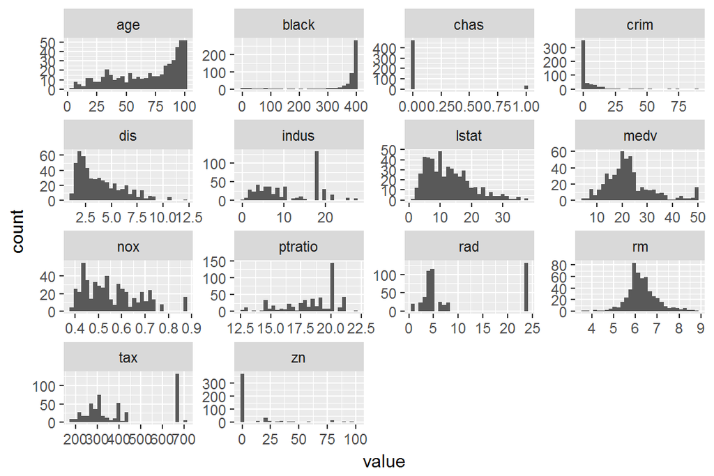

```r
gather(Boston) %>% ggplot(aes(value)) + facet_wrap("key", scales = "free") + geom_histogram()
```

```r
summary(Boston)
```

```
##       crim                zn             indus            chas
##  Min.   : 0.00632   Min.   :  0.00   Min.   : 0.46   Min.   :0.00000
##  1st Qu.: 0.08204   1st Qu.:  0.00   1st Qu.: 5.19   1st Qu.:0.00000
##  Median : 0.25651   Median :  0.00   Median : 9.69   Median :0.00000
##  Mean   : 3.61352   Mean   : 11.36   Mean   :11.14   Mean   :0.06917
##  3rd Qu.: 3.67708   3rd Qu.: 12.50   3rd Qu.:18.10   3rd Qu.:0.00000
##  Max.   :88.97620   Max.   :100.00   Max.   :27.74   Max.   :1.00000
##       nox               rm             age              dis
##  Min.   :0.3850   Min.   :3.561   Min.   :  2.90   Min.   : 1.130
##  1st Qu.:0.4490   1st Qu.:5.886   1st Qu.: 45.02   1st Qu.: 2.100
##  Median :0.5380   Median :6.208   Median : 77.50   Median : 3.207
##  Mean   :0.5547   Mean   :6.285   Mean   : 68.57   Mean   : 3.795
##  3rd Qu.:0.6240   3rd Qu.:6.623   3rd Qu.: 94.08   3rd Qu.: 5.188
##  Max.   :0.8710   Max.   :8.780   Max.   :100.00   Max.   :12.127
##       rad              tax           ptratio          black
##  Min.   : 1.000   Min.   :187.0   Min.   :12.60   Min.   :  0.32
##  1st Qu.: 4.000   1st Qu.:279.0   1st Qu.:17.40   1st Qu.:375.38
##  Median : 5.000   Median :330.0   Median :19.05   Median :391.44
##  Mean   : 9.549   Mean   :408.2   Mean   :18.46   Mean   :356.67
##  3rd Qu.:24.000   3rd Qu.:666.0   3rd Qu.:20.20   3rd Qu.:396.23
##  Max.   :24.000   Max.   :711.0   Max.   :22.00   Max.   :396.90
##      lstat            medv
##  Min.   : 1.73   Min.   : 5.00
##  1st Qu.: 6.95   1st Qu.:17.02
##  Median :11.36   Median :21.20
##  Mean   :12.65   Mean   :22.53
##  3rd Qu.:16.95   3rd Qu.:25.00
##  Max.   :37.97   Max.   :50.00
```

```r
library(corrplot)
bos <- cor(Boston)
round(bos, 2)
```

```
##          crim    zn indus  chas   nox    rm   age   dis   rad   tax
## crim     1.00 -0.20  0.41 -0.06  0.42 -0.22  0.35 -0.38  0.63  0.58
## zn      -0.20  1.00 -0.53 -0.04 -0.52  0.31 -0.57  0.66 -0.31 -0.31
## indus    0.41 -0.53  1.00  0.06  0.76 -0.39  0.64 -0.71  0.60  0.72
## chas    -0.06 -0.04  0.06  1.00  0.09  0.09  0.09 -0.10 -0.01 -0.04
## nox      0.42 -0.52  0.76  0.09  1.00 -0.30  0.73 -0.77  0.61  0.67
## rm      -0.22  0.31 -0.39  0.09 -0.30  1.00 -0.24  0.21 -0.21 -0.29
## age      0.35 -0.57  0.64  0.09  0.73 -0.24  1.00 -0.75  0.46  0.51
## dis     -0.38  0.66 -0.71 -0.10 -0.77  0.21 -0.75  1.00 -0.49 -0.53
## rad      0.63 -0.31  0.60 -0.01  0.61 -0.21  0.46 -0.49  1.00  0.91
## tax      0.58 -0.31  0.72 -0.04  0.67 -0.29  0.51 -0.53  0.91  1.00
## ptratio  0.29 -0.39  0.38 -0.12  0.19 -0.36  0.26 -0.23  0.46  0.46
## black   -0.39  0.18 -0.36  0.05 -0.38  0.13 -0.27  0.29 -0.44 -0.44
## lstat    0.46 -0.41  0.60 -0.05  0.59 -0.61  0.60 -0.50  0.49  0.54
## medv    -0.39  0.36 -0.48  0.18 -0.43  0.70 -0.38  0.25 -0.38 -0.47
##         ptratio black lstat  medv
## crim       0.29 -0.39  0.46 -0.39
## zn        -0.39  0.18 -0.41  0.36
## indus      0.38 -0.36  0.60 -0.48
## chas      -0.12  0.05 -0.05  0.18
## nox        0.19 -0.38  0.59 -0.43
## rm        -0.36  0.13 -0.61  0.70
## age        0.26 -0.27  0.60 -0.38
## dis       -0.23  0.29 -0.50  0.25
## rad        0.46 -0.44  0.49 -0.38
## tax        0.46 -0.44  0.54 -0.47
## ptratio    1.00 -0.18  0.37 -0.51
## black     -0.18  1.00 -0.37  0.33
## lstat      0.37 -0.37  1.00 -0.74
## medv      -0.51  0.33 -0.74  1.00
```

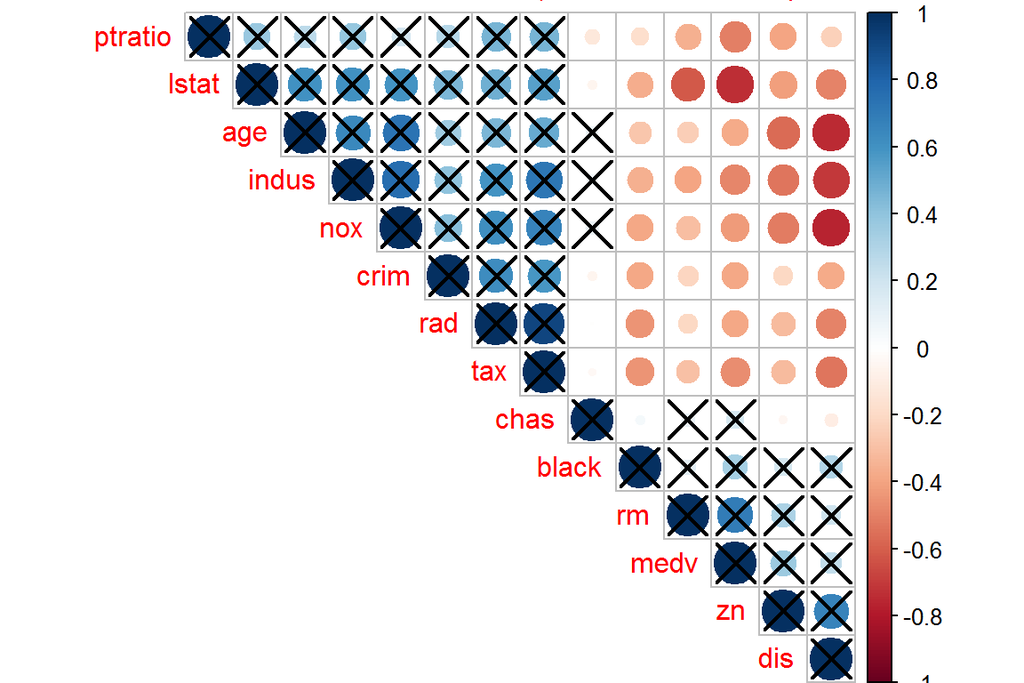

```r
corrplot(bos, type="upper", order="hclust",
         p.mat = bos)
```

Next, I scaled the Boston data. The Scaling was done by substracting the column means from the corresponding columns and dividing the difference with standard deviation. As a result of the scaling all variable means were set to zero. Scaling the data frame changes the data type to matrix for which reason I had to change it back to data frame after the scaling was done.

```r
bostonZ <- scale(Boston)
summary(bostonZ)
```

```
##       crim                 zn               indus
##  Min.   :-0.419367   Min.   :-0.48724   Min.   :-1.5563
##  1st Qu.:-0.410563   1st Qu.:-0.48724   1st Qu.:-0.8668
##  Median :-0.390280   Median :-0.48724   Median :-0.2109
##  Mean   : 0.000000   Mean   : 0.00000   Mean   : 0.0000
##  3rd Qu.: 0.007389   3rd Qu.: 0.04872   3rd Qu.: 1.0150
##  Max.   : 9.924110   Max.   : 3.80047   Max.   : 2.4202
##       chas              nox                rm               age
##  Min.   :-0.2723   Min.   :-1.4644   Min.   :-3.8764   Min.   :-2.3331
##  1st Qu.:-0.2723   1st Qu.:-0.9121   1st Qu.:-0.5681   1st Qu.:-0.8366
##  Median :-0.2723   Median :-0.1441   Median :-0.1084   Median : 0.3171
##  Mean   : 0.0000   Mean   : 0.0000   Mean   : 0.0000   Mean   : 0.0000
##  3rd Qu.:-0.2723   3rd Qu.: 0.5981   3rd Qu.: 0.4823   3rd Qu.: 0.9059
##  Max.   : 3.6648   Max.   : 2.7296   Max.   : 3.5515   Max.   : 1.1164
##       dis               rad               tax             ptratio
##  Min.   :-1.2658   Min.   :-0.9819   Min.   :-1.3127   Min.   :-2.7047
##  1st Qu.:-0.8049   1st Qu.:-0.6373   1st Qu.:-0.7668   1st Qu.:-0.4876
##  Median :-0.2790   Median :-0.5225   Median :-0.4642   Median : 0.2746
##  Mean   : 0.0000   Mean   : 0.0000   Mean   : 0.0000   Mean   : 0.0000
##  3rd Qu.: 0.6617   3rd Qu.: 1.6596   3rd Qu.: 1.5294   3rd Qu.: 0.8058
##  Max.   : 3.9566   Max.   : 1.6596   Max.   : 1.7964   Max.   : 1.6372
##      black             lstat              medv
##  Min.   :-3.9033   Min.   :-1.5296   Min.   :-1.9063
##  1st Qu.: 0.2049   1st Qu.:-0.7986   1st Qu.:-0.5989
##  Median : 0.3808   Median :-0.1811   Median :-0.1449
##  Mean   : 0.0000   Mean   : 0.0000   Mean   : 0.0000
##  3rd Qu.: 0.4332   3rd Qu.: 0.6024   3rd Qu.: 0.2683
##  Max.   : 0.4406   Max.   : 3.5453   Max.   : 2.9865
```

```r
bostonZ <- as.data.frame(bostonZ)
```

The crim variabe was then categorized cutting it to quantiles.

```r
scaled_crim <- bostonZ$crim
# creatING a quantile vector of crim
bins <- quantile(scaled_crim)
# setting the quantiles as the break points and creating a categorical crime variable
crime <- cut(scaled_crim, breaks = bins, include.lowest = TRUE, label = c("low", "med_low", "med_high", "high"))
# remove the crim
bostonZ <- dplyr::select(bostonZ, -crim)
# add the crime
bostonZ <- data.frame(bostonZ, crime)
#
```

After creating the categorical crime variable I splitted the scaled Boston data to two sets: training set and test set. The training set consisted of 80% randomly chosen observations whereas the test set consisted of the remaining 20% of the rows.

```r
# defining the number of rows in the scaled Boston dataset
n <- nrow(bostonZ)

# randomly choosing 80% of the rows
ind <- sample(n,  size = n * 0.8)

# creating a train set
train <- bostonZ[ind,]

# creating a test set
test <- bostonZ[-ind,]

# saving the correct classes from test data to a separate vector
correct_classes <- test$crime

# removing the crime variable from test data
test <- dplyr::select(test, -crime)
```

The training set was used for creating a linear discriminant analysis (LDA) functions that could be later utilized to cluster new set of observations to correct classes of crime. The purpose of linear discriminant analysis was to find the linear combinations of the continuous variables (13 variables from the boston data) giving the best possible separation between the groups (crime quantiles). The maximum number of estimated discriminant functions is usually defined as the amount of groups (crime quantiles) subtracted by 1 (in this case 3 discriminant functions).

```r
# Running linear discriminant analysis (lda) on the train data crime set as the target
lda.fit <- lda(crime ~ ., data = train)
lda.fit
```

```
## Call:
## lda(crime ~ ., data = train)
##
## Prior probabilities of groups:
##       low   med_low  med_high      high
## 0.2500000 0.2549505 0.2351485 0.2599010
##
## Group means:
##                  zn      indus        chas        nox         rm
## low       0.9357713 -0.9031730 -0.11640431 -0.8824175  0.4320047
## med_low  -0.1383951 -0.2693515  0.03346513 -0.5479239 -0.1262042
## med_high -0.3780163  0.2130104  0.10065938  0.4246737  0.1521489
## high     -0.4872402  1.0170492 -0.12234430  1.0046735 -0.4656822
##                 age        dis        rad        tax     ptratio
## low      -0.9195332  0.8466192 -0.6850891 -0.7386775 -0.42032884
## med_low  -0.2788279  0.3311495 -0.5470148 -0.4941107 -0.08977988
## med_high  0.4082373 -0.4031942 -0.3822505 -0.2811519 -0.29452882
## high      0.8016683 -0.8580202  1.6388211  1.5145512  0.78158339
##                black       lstat         medv
## low       0.38722346 -0.77913561  0.528994065
## med_low   0.32126083 -0.09277062  0.003927945
## med_high  0.06883387  0.01444425  0.184020624
## high     -0.85584988  0.90393172 -0.710000574
##
## Coefficients of linear discriminants:
##                 LD1         LD2         LD3
## zn       0.06163996  0.77297271 -0.92505862
## indus    0.03652354 -0.32883761  0.21219098
## chas    -0.08567527 -0.03515382  0.19862814
## nox      0.35767247 -0.66362145 -1.45762092
## rm      -0.07538515 -0.14042808 -0.21568534
## age      0.23374449 -0.30608987  0.03858216
## dis     -0.08264963 -0.25456572  0.22098891
## rad      2.98589231  0.86927965  0.03336568
## tax      0.00341723  0.01950667  0.48543016
## ptratio  0.07628444  0.07512975 -0.34390370
## black   -0.12603781 -0.01875339  0.09278499
## lstat    0.23510854 -0.20974089  0.39923674
## medv     0.19261210 -0.34210930 -0.16639603
##
## Proportion of trace:
##    LD1    LD2    LD3
## 0.9420 0.0424 0.0156
```

when creating the biplot of the model also the so-called biplot arrows were added. A separate function was used for adding the arrows to the biplot. As revealed by the biplot, the **** first discriminant function (LD1) separates high crime class from other classes but doesn’t perfectly separate low, med_low and med_high. LD2 is unable to separate the high from other classes but performs relatively well in separating low from med_high. There is, however, no perfect dimension to separate the med_low and med_high levels.

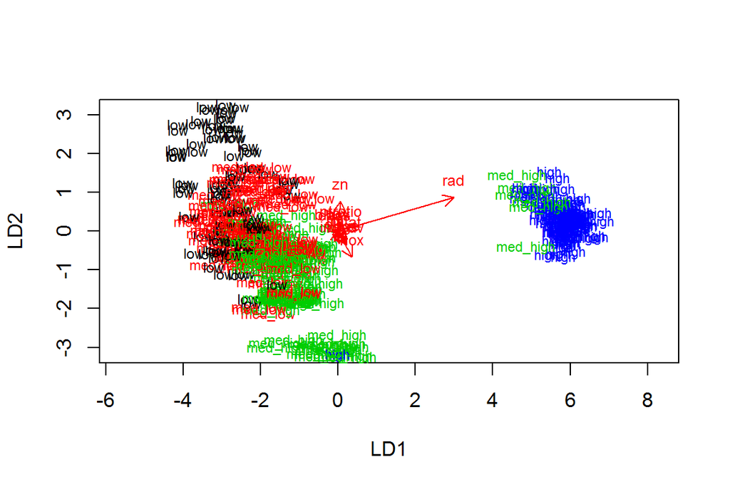

```r
# the function for lda biplot arrows
lda.arrows <- function(x, myscale = 1, arrow_heads = 0.1, color = "red", tex = 0.75, choices = c(1,2)){
  heads <- coef(x)
  arrows(x0 = 0, y0 = 0,
         x1 = myscale * heads[,choices[1]],
         y1 = myscale * heads[,choices[2]], col=color, length = arrow_heads)
  text(myscale * heads[,choices], labels = row.names(heads),
       cex = tex, col=color, pos=3)
}

# target classes as numeric
classes <- as.numeric(train$crime)

# plot the lda results
plot(lda.fit, dimen = 2, col = classes, pch = classes)
lda.arrows(lda.fit, myscale = 1)
```

```r
# using the model to predict crime classes in the test data
lda.pred <- predict(lda.fit, newdata = test)

# cross tabulate the results
table(correct = correct_classes, predicted = lda.pred$class)
```

```
##           predicted
## correct    low med_low med_high high
##   low       12      13        1    0
##   med_low    5      16        2    0
##   med_high   0      15       16    0
##   high       0       0        0   22
```

After clustering the Boston data with the LDA, I moved on to k-means method. K-means is an unsupervised clustering method, that is it does not require training. Consecuently, it does not know the correct amount of clusters. For that reason, I had to first run the kmeans model several times for different amount of clusters (1:10). To see, which cluster amount works best, I calculated the total within subject squares of each solution and plotted that against the cluster number (x-axis).

```r
data('Boston')

BostonScaled <- scale(Boston)

set.seed(123)

# euclidean distance matrix
dist_eu <- dist(BostonScaled)
summary(dist_eu)
```

```
##    Min. 1st Qu.  Median    Mean 3rd Qu.    Max.
##  0.1343  3.4620  4.8240  4.9110  6.1860 14.4000
```